# CFS Recall (Master’s Expt 2), 2 Apertures

pss

15 October, 2017

7 participants worth of data. They were recruited through SONA or were RAs. 120 items per participant, encountered in lists of 12 items. With three conditions (binocular, cfs, not-studied), there were four items in each condition in each list. Of those four items, three were encountered in a “go” test trial, and one was in a “no-go” test trial. So, 1/4 of test-trials were no-go. This leaves up to 30 items in go trials per condition, per participant.

Previous updates

- Binocular objects were studied for up to 5 seconds (rather than up to 4 seconds)
- All objects that were studied (CFS or Binocular) reached 100% opacity after 2.5 seconds
- The above point means that there was no variability / calibration of opacity to each participant

The primary goal of these modification was in improve naming performance for items that were studied binocularly. However, there was a bug in the code when labelling the condition of the items. So, these modifications was not necessary as Naming performance was already okay for binocularly studied objects.

## Figures

Note that in this group-level plot (and all other following), each participants’ average performance is calculated separetely and then averaged together. Error bars reflect the bootstrapped 95% CI of the averaging across participant averages.

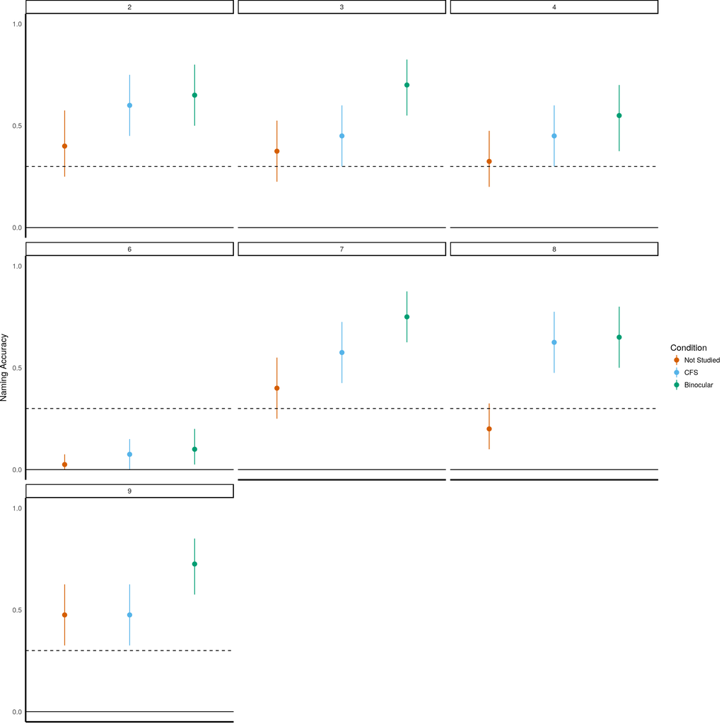

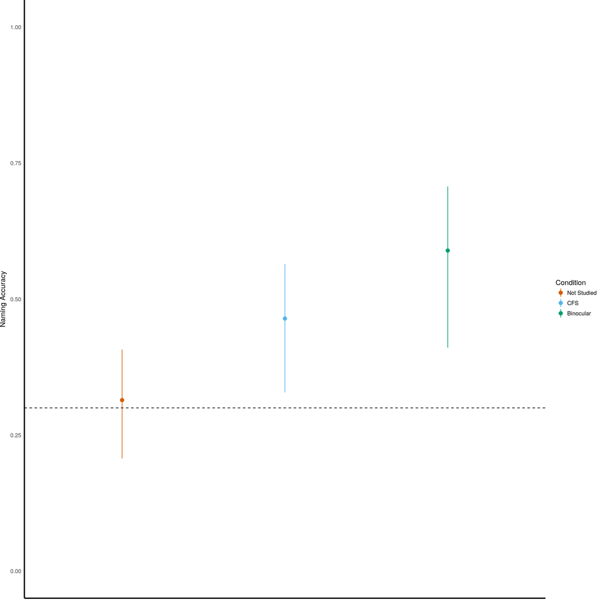

The following plot shows proportion correct on the no/no-go trials (whether participants either said an item was appearing, or correctly waited). Raw accuracy is high. I didn’t calculate anything like d’ given that performance was basically at ceiling for all participants, and so d’ would be infinity.

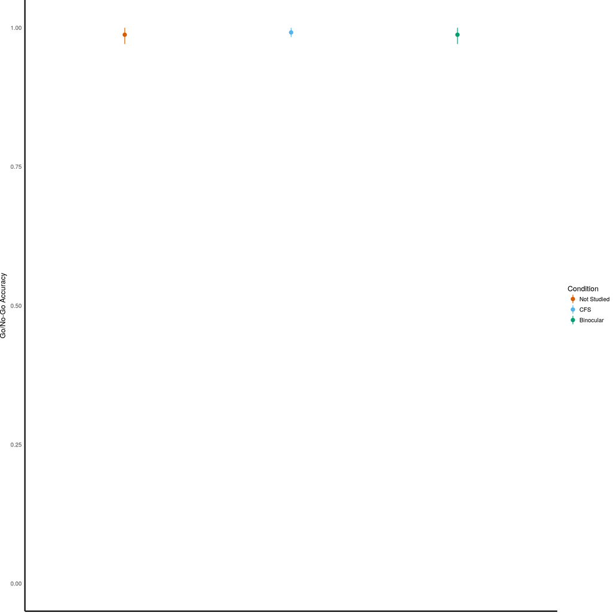

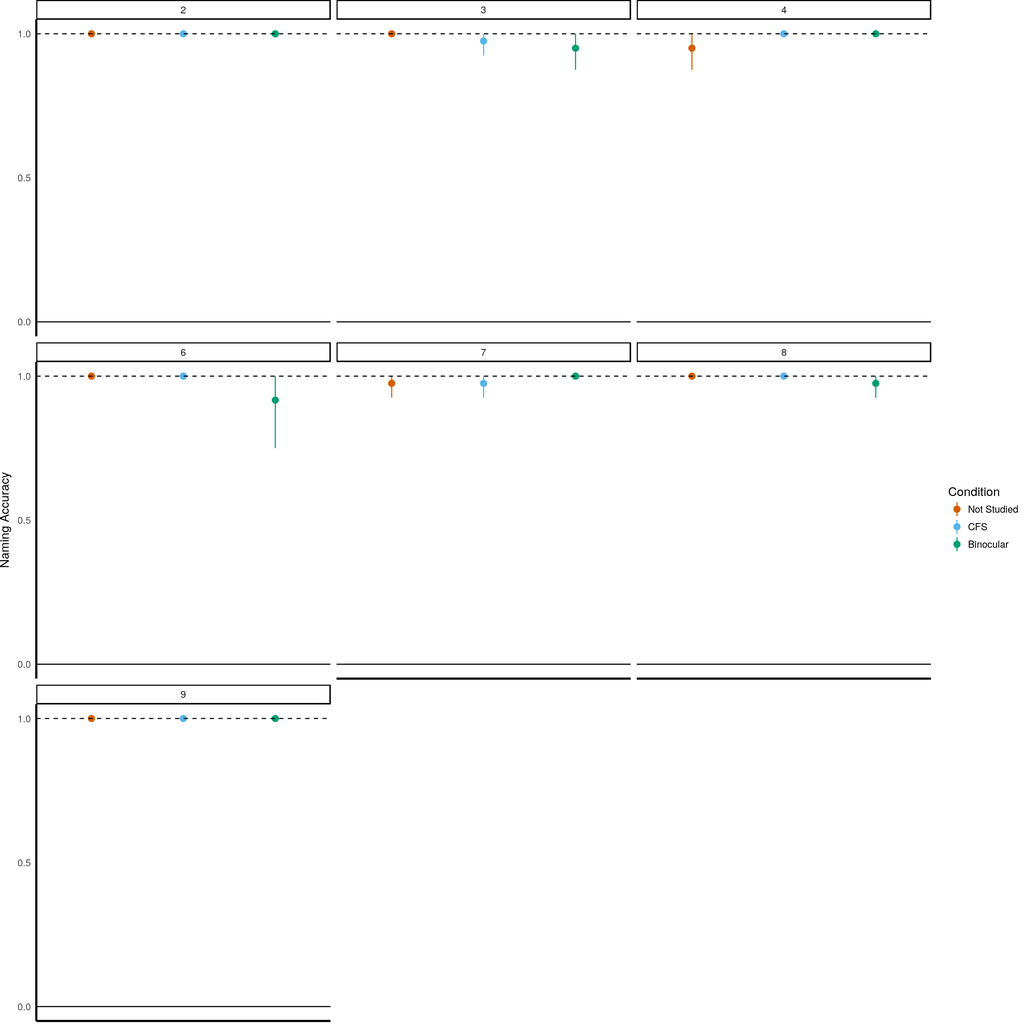

Percentiles are first calculated within participants, then averaged across participants. Points correspond to the .2, .4, .6, .8, and 1 quintiles.

Note that because these lines are conditioned on accurately naming the cue item, there are different numbers of trial in each condition.

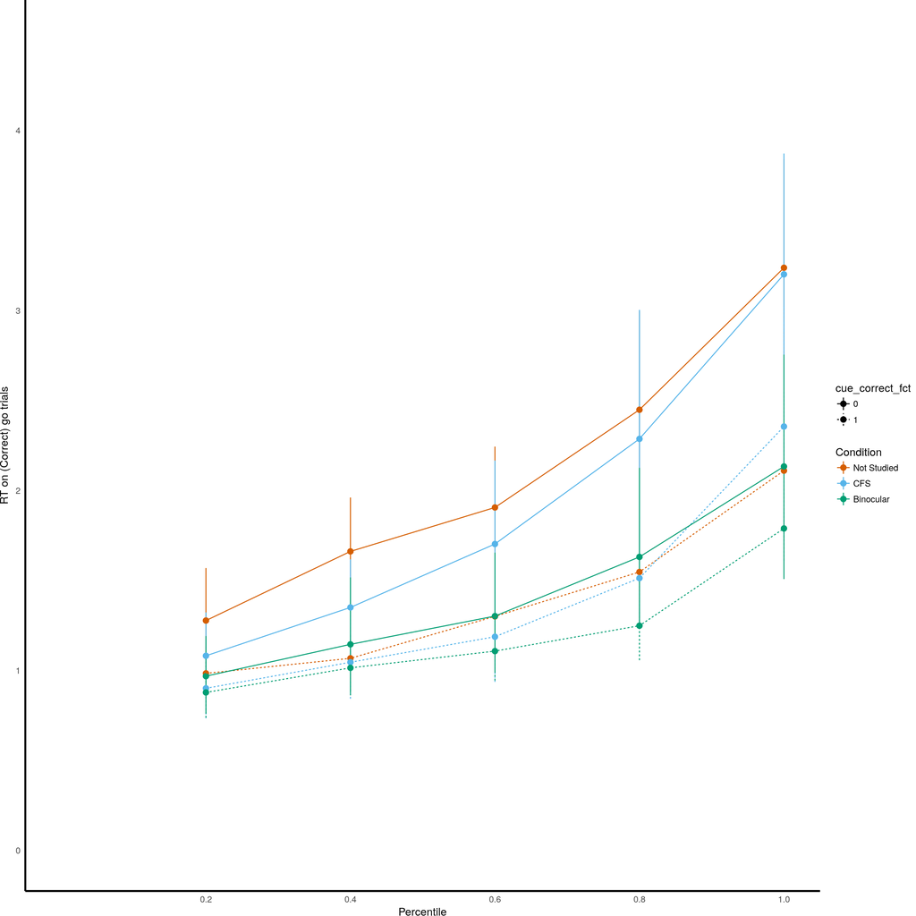

These cdf plots are shown for each participant, once with Percentile on the x-axis and once with the axes swapped

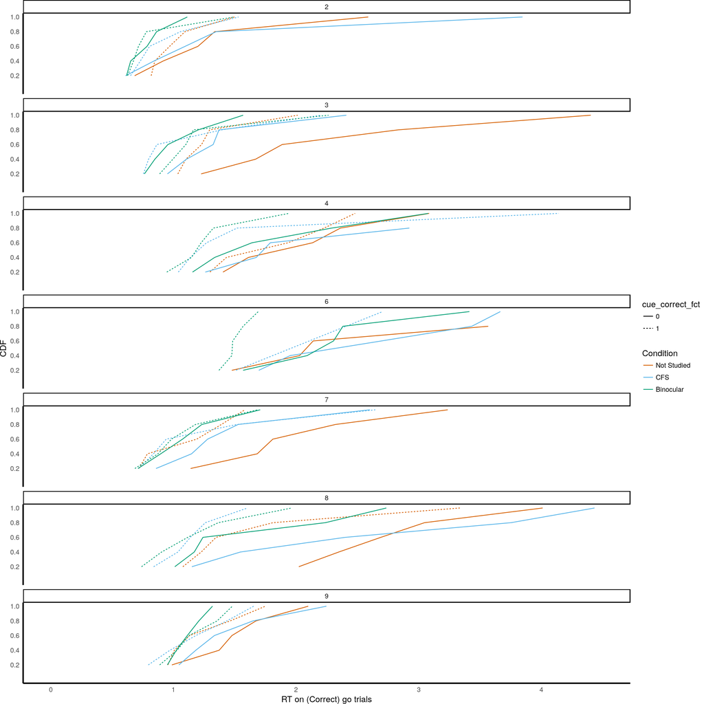

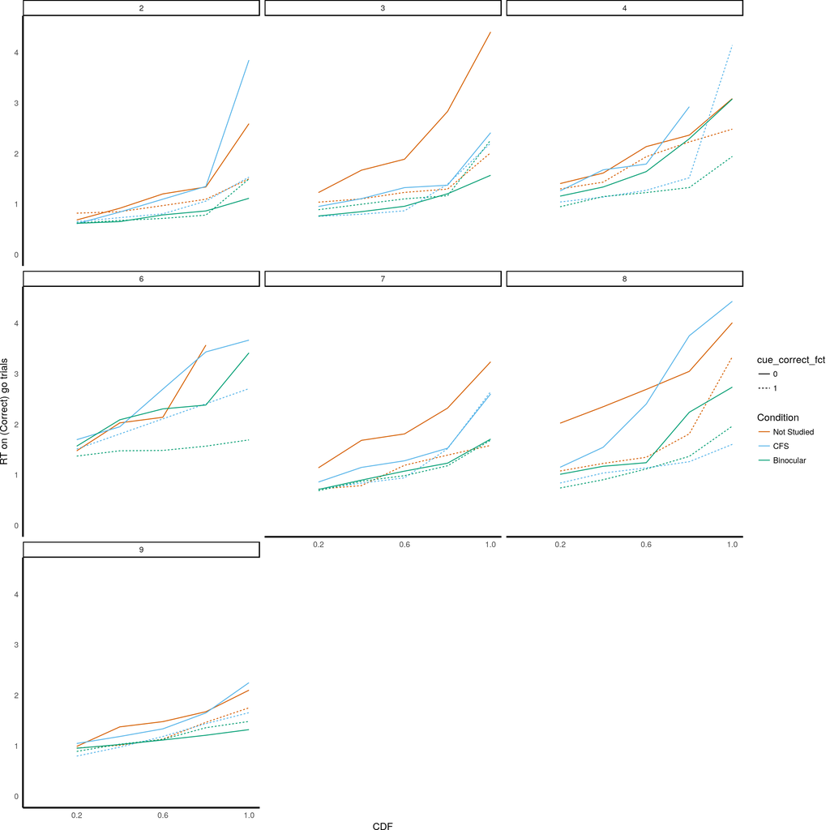

Here is a bit more detail about each participant’s reaction time.

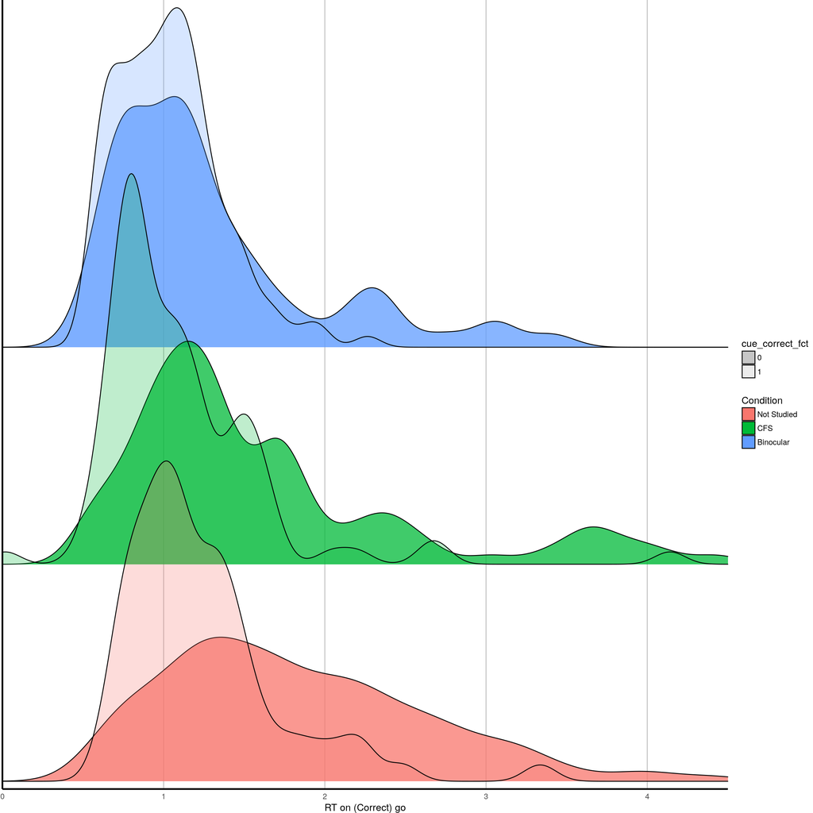

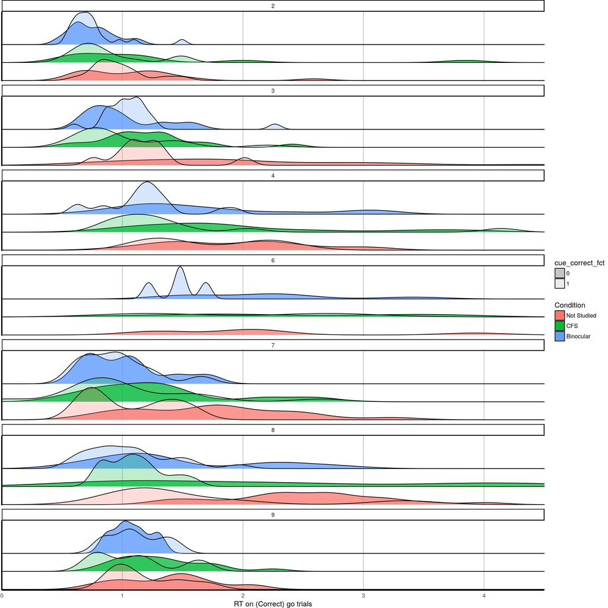

Finally, here are the empirical cdfs. In these plots, there is no collapsing across quintiles. The RTs are just ordered. Here, it’s a little easier to see where an effect might be emerging in the data.

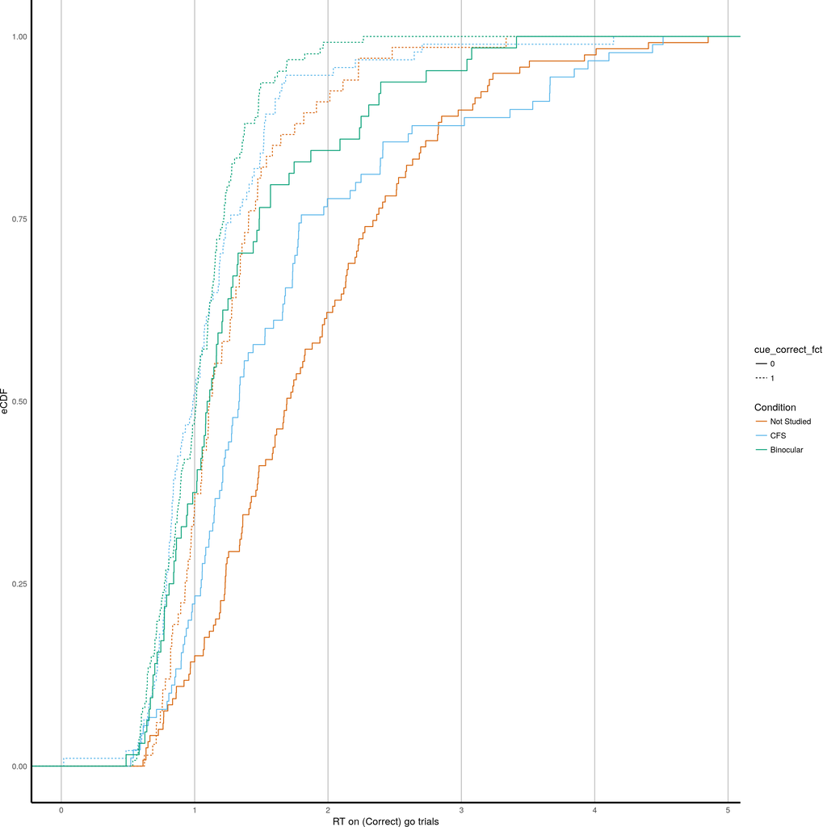

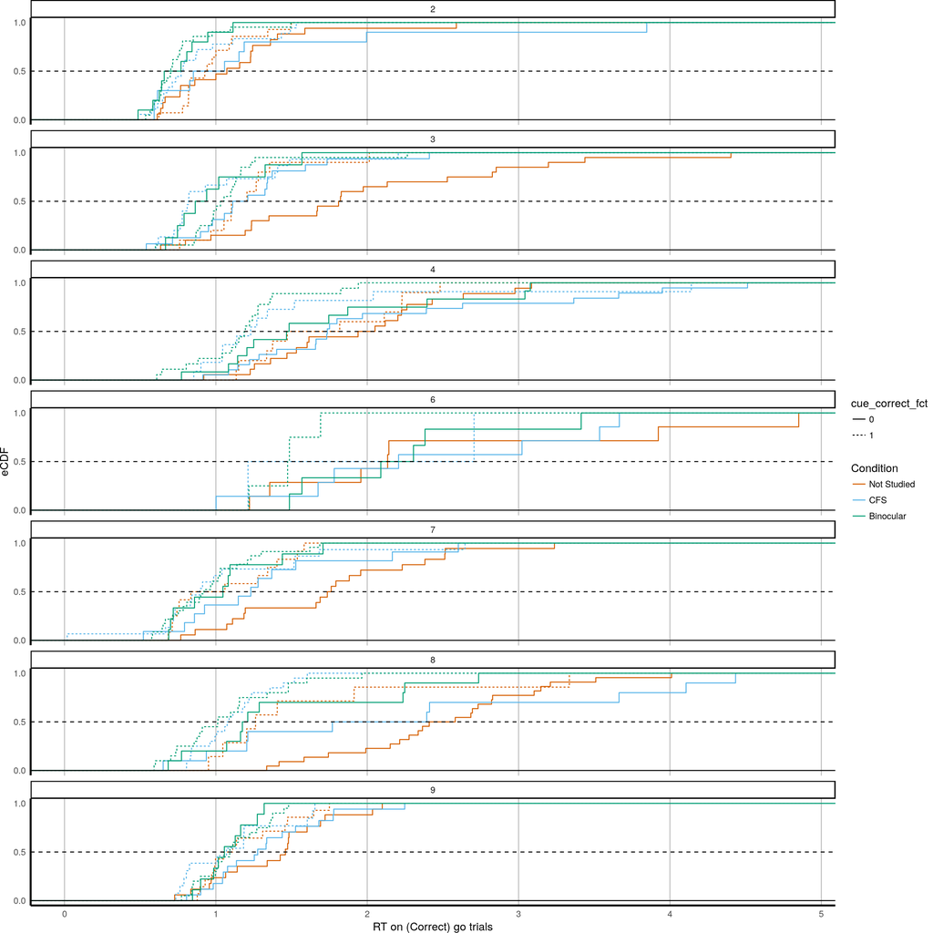